# pathways(): the bridge between the three families

honets

2026-08-26

## The analytic question

The three structure families in honets are entry points into one another, not islands. `pathways()` is the generic that carries a fitted **memory network** across to the other two: it extracts the paths the model considers real and returns them as plain strings, which `build_simplicial(type = "pathway")` turns into a complex.

It is a small verb doing one job, and it is the reason a HON can be handed to a topological analysis without any manual reshaping.

```r
library(honets)
seqs <- split(human_long$code, human_long$session_id)
```

```r
library(cograph)
```

## Three methods, one generic

`pathways()` dispatches on `net_hon`, `net_hypa` and `net_mogen`. Each returns the paths that model regards as meaningful — which is a *different set* in each case, because the three models mean different things by “meaningful”.

```r
hon <- build_hon(seqs, max_order = 2, min_freq = 50)
p_hon <- pathways(hon)
length(p_hon)
```

```
[1] 25
```

```r
pathways(hon, top = 6)
```

```
[1] "Specify Command -> Specify"   "Command Request -> Specify"
[3] "Specify Command -> Request"   "Request Specify -> Interrupt"
[5] "Command Command -> Command"   "Command Specify -> Interrupt"
```

From a HON: the extracted rules — contexts that earned their own node. 25 of them at `min_freq = 50`.

```r
hp <- build_hypa(seqs, order = 2)
p_hypa <- pathways(hp)
length(p_hypa)
```

```
[1] 185
```

```r
pathways(hp, top = 4)
```

[output not shown]

[output cut: 78 more lines]

From HYPA: the **anomalous** paths — those significantly over- or under-represented against the degree-preserving null. 185 of them. Note the first entry, `Interrupt Interrupt -> Interrupt`: the same repeated- interruption pattern that `path_dependence()` flags as the highest-divergence context.

```r
mo <- build_mogen(seqs, max_order = 2)
p_mogen <- pathways(mo)
length(p_mogen)
```

```
[1] 702
```

```r
pathways(mo, top = 4)
```

```
[1] "Specify Command -> Specify"   "Command Request -> Specify"
[3] "Specify Command -> Request"   "Request Specify -> Interrupt"
```

From MOGen: every path in the fitted layer — 702, the complete second-order transition set, because a multi-order model does not prune.

## The format

Each string is `"<context states, space separated> -> <next state>"`. The context uses spaces so that the arrow separates history from continuation unambiguously.

```r
p_hon[1]
```

```
[1] "Specify Command -> Specify"
```

Read as: the context `Specify Command` continuing to `Specify`.

## Crossing to the simplicial family

```r
sc <- build_simplicial(hon, type = "pathway")
sc
```

```
Pathway Complex
  9 nodes, 29 simplices, dimension 2
  Density: 22.5%  |  Mean dim: 0.90  |  Euler: 1
  f-vector: (f0=9 f1=14 f2=6)
  Betti: b0=2 b1=1
  Nodes: Command, Correct, Frustrate, Inquire, Interrupt, Refine, Request, Specify, Verify
```

`build_simplicial()` calls `pathways()` internally — you rarely need to call it yourself. Each path becomes a simplex, and because a simplicial complex is closed under subsets, so does every sub-path. The result has a geometry, and therefore a topology: `b0 = 2` says the well-evidenced pathways fall into **two disconnected groups** of actions, and `b1 = 1` says there is one one-dimensional hole — a cycle of actions that is never closed by an observed pathway.

Neither statement is available from the transition network the paths came from.

## Seeing them

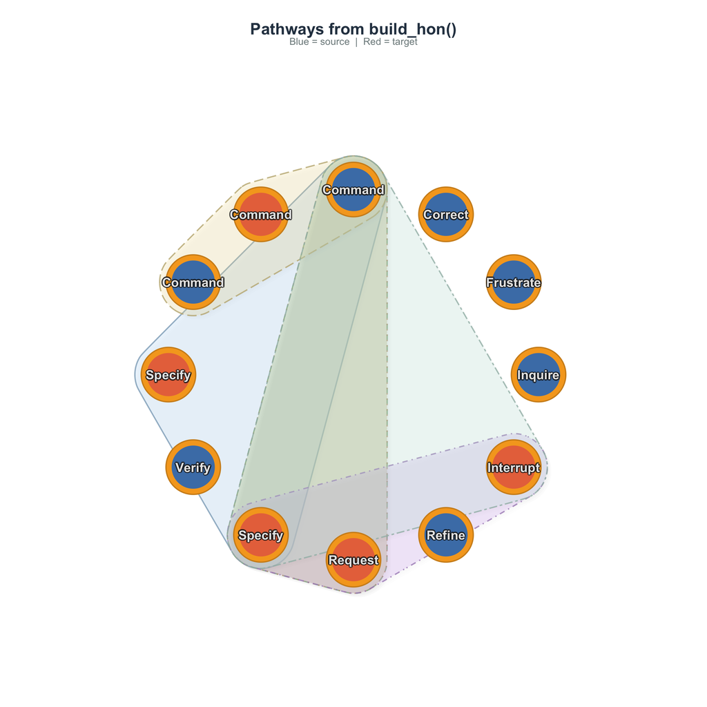

```r
net1 <- build_hon(seqs, max_order = 1)
plot_simplicial(net1,
                pathways = as.data.frame(hon, order_min = 2,
                                         sort_by = "count", top = 6),
                max_pathways = 6, title = "Pathways from build_hon()")
```

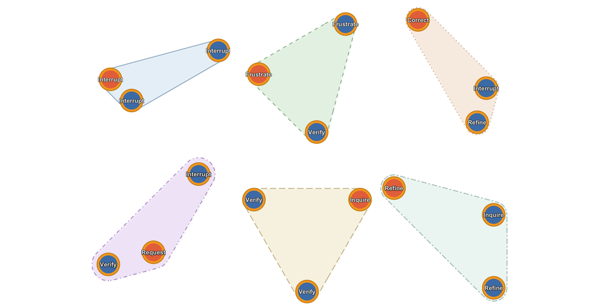

```r
plot_simplicial(hp, anomaly = "over", max_pathways = 6,
                dismantled = TRUE, ncol = 3)
```

## The choice of source model matters

Because the three models select different paths, they build different complexes:

```r
do.call(rbind, lapply(
  list(HON = hon, HYPA = hp, MOGen = mo),
  function(m) {
    s <- build_simplicial(m, type = "pathway")
    data.frame(paths = length(pathways(m)), simplices = s$n_simplices,
               dimension = s$dimension, b0 = betti_numbers(s)[1])
  }))
```

```
      paths simplices dimension b0
HON      25        29         2  2
HYPA    185       105         2  1
MOGen   702       129         2  1
```

MOGen’s 702 unpruned paths produce a dense, connected complex; HON’s 25 well-evidenced rules produce a sparse, disconnected one. **The topology you report is a property of the model you chose**, not of the raw sequences — say which model, and say why.

## Calling it directly

You would call `pathways()` yourself to inspect what a model considers real, or to feed the paths somewhere else:

```r
# how long are the extracted paths?
table(lengths(strsplit(p_hon, " ", fixed = TRUE)))
```

```
 4
25
```

## What to do next

- **`build_simplicial()`** — the main consumer, and where the topology gets computed.
- **`build_hon()`**, **`build_hypa()`**, **`build_mogen()`** — the three producers.
- **`window_hypergraph()`** — the other route out of sequence data, into the hypergraph family.

## References

- Xu, J., Wickramarathne, T. L., & Chawla, N. V. (2016). Representing higher-order dependencies in networks. *Science Advances*, 2(5), e1600028.
- Battiston, F., et al. (2020). Networks beyond pairwise interactions. *Physics Reports*, 874, 1-92.